# BMW vs Volkswagen

Iker Aguirre Otaegui

11/29/2020

El presente trabajo tiene como objetivo estudiar las series de precios de las acciones de BMW y Volkswagen, de las multinacionales del sector automovilístico. Para ello, nos serviremos de todos los valores registrados desde el 1 de enero de 2014 hasta la fecha. Los datos serán obtenidos mediante el paquete quantmod, el cual extrae la información financiera de plataformas como Google Finance o Yahoo Finance.

Para el estudio, Haremos uso de los modelos Garch, para BMW, y VAR, para ambas compañías.

```r
bmw <- getSymbols("BMW.DE", from = "2014-01-01", to = "2020-11-20", auto.assign = FALSE)
```

[output not shown]

```r
volks <- getSymbols("VOW.DE", from = "2014-01-01", to = "2020-11-20", auto.assign = FALSE)
bmw.ad = Ad(bmw)
volks.ad = Ad(volks)
```

Para el estudio, Haremos uso de los modelos Garch, para BMW, y VAR, para ambas compañías.

## 1. GARCH con BMW

El modelo GARCH es un modelo utilizado frecuentemente en el estudio de la volatilidad en los rendimientos en una serie temporal dada.

```r
t.test(bmw.rent)
```

```
##
##  One Sample t-test
##
## data:  bmw.rent
## t = 0.22912, df = 1742, p-value = 0.8188
## alternative hypothesis: true mean is not equal to 0
## 95 percent confidence interval:
##  -0.0007344858  0.0009287887
## sample estimates:
##    mean of x
## 9.715144e-05
```

A continuación, representamos la función de autocorrelación y la autocorrelación parcial.

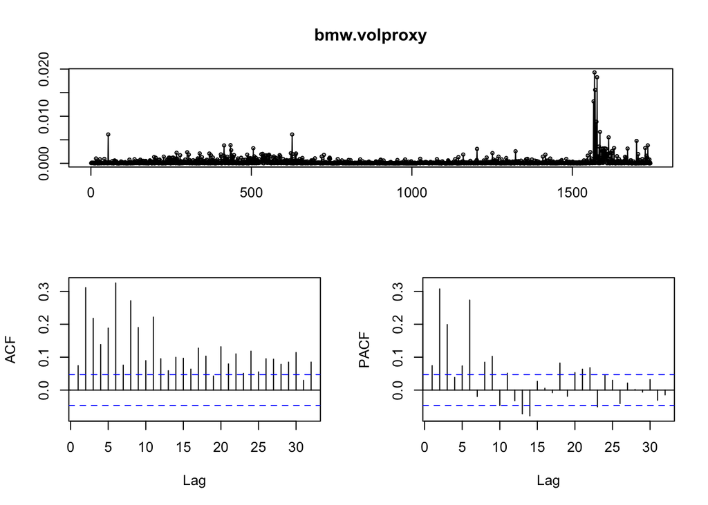

```r
bmw.volproxy = bmw.rent^2
tsdisplay(bmw.volproxy)
```

Podemos observar una claro pico de volatilidad en la serie, probablemente resultado del incicio de la pandemia mundial por Covid-19.

Aplicamos el Ljung-Box test para comprobar si las autocorrelaciones son iguales a 0.

```r
Box.test(bmw.volproxy,lag=10,  type="Lj")
```

```
##
##  Box-Ljung test
##
## data:  bmw.volproxy
## X-squared = 760.2, df = 10, p-value < 2.2e-16
```

```r
Box.test(bmw.volproxy,lag=20,  type="Lj")
```

```
##
##  Box-Ljung test
##
## data:  bmw.volproxy
## X-squared = 991.15, df = 20, p-value < 2.2e-16
```

```r
Box.test(bmw.volproxy,lag=40,  type="Lj")
```

```
##
##  Box-Ljung test
##
## data:  bmw.volproxy
## X-squared = 1228.2, df = 40, p-value < 2.2e-16
```

Contruimos un modelo ARCH(1).

```r
bmw.arch = garchFit(~1 + garch(1,0), data = bmw.rent, trace = F)
summary(bmw.arch)
```

```
##
## Title:
##  GARCH Modelling
##
## Call:
##  garchFit(formula = ~1 + garch(1, 0), data = bmw.rent, trace = F)
##
## Mean and Variance Equation:
##  data ~ 1 + garch(1, 0)
## <environment: 0x7ff2509afe68>
##  [data = bmw.rent]
##
## Conditional Distribution:
##  norm
##
## Coefficient(s):
##         mu       omega      alpha1
## 0.00016803  0.00022991  0.31928300
##
## Std. Errors:
##  based on Hessian
##
## Error Analysis:
##         Estimate  Std. Error  t value Pr(>|t|)
## mu     0.0001680   0.0003911    0.430    0.667
## omega  0.0002299   0.0000104   22.116  < 2e-16 ***
## alpha1 0.3192830   0.0457047    6.986 2.83e-12 ***
## ---
## Signif. codes:  0 '***' 0.001 '**' 0.01 '*' 0.05 '.' 0.1 ' ' 1
##
## Log Likelihood:
##  4612.703    normalized:  2.646416
##
## Description:
##  Mon Nov 30 17:14:46 2020 by user:
##
##
## Standardised Residuals Tests:
##                                 Statistic p-Value
##  Jarque-Bera Test   R    Chi^2  3775.781  0
##  Shapiro-Wilk Test  R    W      0.9374354 0
##  Ljung-Box Test     R    Q(10)  23.49578  0.009057351
##  Ljung-Box Test     R    Q(15)  31.70679  0.00705628
##  Ljung-Box Test     R    Q(20)  37.60029  0.009905389
##  Ljung-Box Test     R^2  Q(10)  317.7572  0
##  Ljung-Box Test     R^2  Q(15)  380.1394  0
##  Ljung-Box Test     R^2  Q(20)  471.9584  0
##  LM Arch Test       R    TR^2   231.7435  0
##
## Information Criterion Statistics:
##       AIC       BIC       SIC      HQIC
## -5.289390 -5.279986 -5.289396 -5.285913
```

```r
resi = residuals(bmw.arch, standardize = T)
```

A continuación, creamos un GARCH (1,1)

```r
bmw.garch = fGarch::garchFit(~1 + garch(1,1), data = bmw.rent, trace = F)
summary(bmw.garch)
```

```
##
## Title:
##  GARCH Modelling
##
## Call:
##  fGarch::garchFit(formula = ~1 + garch(1, 1), data = bmw.rent,
##     trace = F)
##
## Mean and Variance Equation:
##  data ~ 1 + garch(1, 1)
## <environment: 0x7ff2567f7e78>
##  [data = bmw.rent]
##
## Conditional Distribution:
##  norm
##
## Coefficient(s):
##         mu       omega      alpha1       beta1
## 3.0684e-04  2.4947e-06  5.0081e-02  9.4263e-01
##
## Std. Errors:
##  based on Hessian
##
## Error Analysis:
##         Estimate  Std. Error  t value Pr(>|t|)
## mu     3.068e-04   3.362e-04    0.913   0.3615
## omega  2.495e-06   9.797e-07    2.546   0.0109 *
## alpha1 5.008e-02   8.035e-03    6.233 4.58e-10 ***
## beta1  9.426e-01   9.568e-03   98.520  < 2e-16 ***
## ---
## Signif. codes:  0 '***' 0.001 '**' 0.01 '*' 0.05 '.' 0.1 ' ' 1
##
## Log Likelihood:
##  4784.372    normalized:  2.744906
##
## Description:
##  Mon Nov 30 17:14:46 2020 by user:
##
##
## Standardised Residuals Tests:
##                                 Statistic p-Value
##  Jarque-Bera Test   R    Chi^2  749.8794  0
##  Shapiro-Wilk Test  R    W      0.9721869 0
##  Ljung-Box Test     R    Q(10)  22.16379  0.01429161
##  Ljung-Box Test     R    Q(15)  26.52681  0.0328368
##  Ljung-Box Test     R    Q(20)  32.65733  0.03677834
##  Ljung-Box Test     R^2  Q(10)  21.37204  0.01864359
##  Ljung-Box Test     R^2  Q(15)  22.78481  0.08881694
##  Ljung-Box Test     R^2  Q(20)  26.20932  0.1590093
##  LM Arch Test       R    TR^2   21.86715  0.03903594
##
## Information Criterion Statistics:
##       AIC       BIC       SIC      HQIC
## -5.485223 -5.472685 -5.485233 -5.480587
```

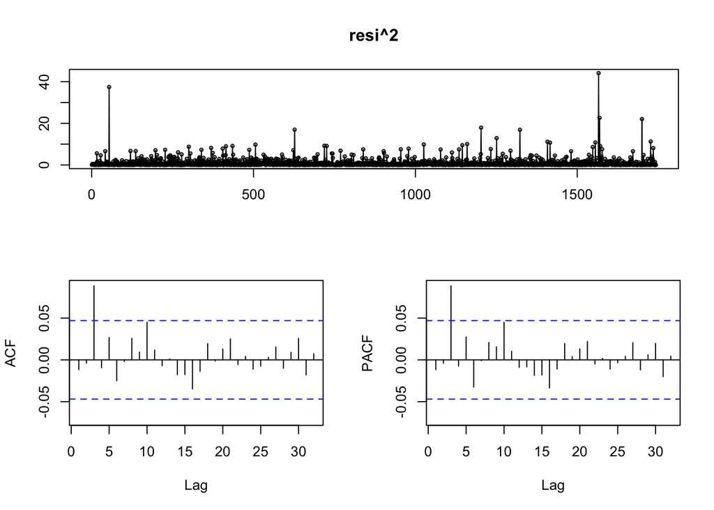

```r
resi = residuals(bmw.garch, standardize=T)
resi = xts(resi, order.by = index(bmw.rent))
tsdisplay(resi^2)
```

Usamos la T-Student en el GARCH(1,1)

```r
bmw.t = garchFit(~1 + garch(1,1), data = bmw.rent, trace = F, cond.dist = "std")
summary(bmw.t)
```

```
##
## Title:
##  GARCH Modelling
##
## Call:
##  garchFit(formula = ~1 + garch(1, 1), data = bmw.rent, cond.dist = "std",
##     trace = F)
##
## Mean and Variance Equation:
##  data ~ 1 + garch(1, 1)
## <environment: 0x7ff256634df8>
##  [data = bmw.rent]
##
## Conditional Distribution:
##  std
##
## Coefficient(s):
##         mu       omega      alpha1       beta1       shape
## 1.2617e-05  2.0402e-06  4.7209e-02  9.4807e-01  4.9641e+00
##
## Std. Errors:
##  based on Hessian
##
## Error Analysis:
##         Estimate  Std. Error  t value Pr(>|t|)
## mu     1.262e-05   3.088e-04    0.041   0.9674
## omega  2.040e-06   9.692e-07    2.105   0.0353 *
## alpha1 4.721e-02   9.980e-03    4.730 2.24e-06 ***
## beta1  9.481e-01   1.053e-02   90.008  < 2e-16 ***
## shape  4.964e+00   6.045e-01    8.212 2.22e-16 ***
## ---
## Signif. codes:  0 '***' 0.001 '**' 0.01 '*' 0.05 '.' 0.1 ' ' 1
##
## Log Likelihood:
##  4856.229    normalized:  2.786133
##
## Description:
##  Mon Nov 30 17:14:46 2020 by user:
##
##
## Standardised Residuals Tests:
##                                 Statistic p-Value
##  Jarque-Bera Test   R    Chi^2  779.5317  0
##  Shapiro-Wilk Test  R    W      0.9718239 0
##  Ljung-Box Test     R    Q(10)  22.35225  0.01340731
##  Ljung-Box Test     R    Q(15)  26.62859  0.03191226
##  Ljung-Box Test     R    Q(20)  32.75372  0.03589998
##  Ljung-Box Test     R^2  Q(10)  24.785    0.005768285
##  Ljung-Box Test     R^2  Q(15)  26.15726  0.03640188
##  Ljung-Box Test     R^2  Q(20)  29.76094  0.07382102
##  LM Arch Test       R    TR^2   25.29787  0.01347274
##
## Information Criterion Statistics:
##       AIC       BIC       SIC      HQIC
## -5.566528 -5.550856 -5.566544 -5.560733
```

Por último, realizamos la predicción.

```r
predict(bmw.t)
```

```
##    meanForecast  meanError standardDeviation
## 1  1.261672e-05 0.02226151        0.02226151
## 2  1.261672e-05 0.02225474        0.02225474
## 3  1.261672e-05 0.02224801        0.02224801
## 4  1.261672e-05 0.02224130        0.02224130
## 5  1.261672e-05 0.02223462        0.02223462
## 6  1.261672e-05 0.02222798        0.02222798
## 7  1.261672e-05 0.02222136        0.02222136
## 8  1.261672e-05 0.02221477        0.02221477
## 9  1.261672e-05 0.02220821        0.02220821
## 10 1.261672e-05 0.02220168        0.02220168
```

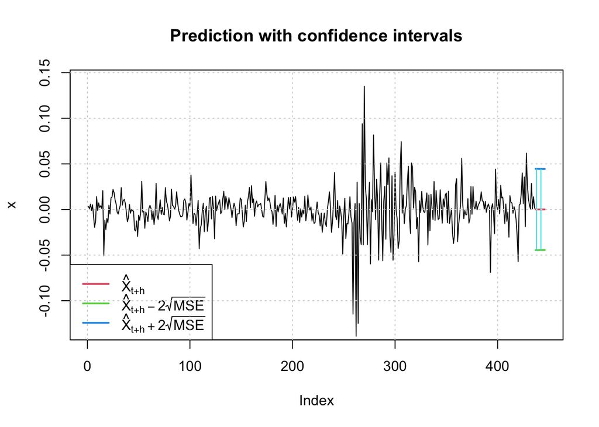

```r
preda = predict(bmw.t, n.ahead = 10, plot=TRUE, crit_val = 2)
```

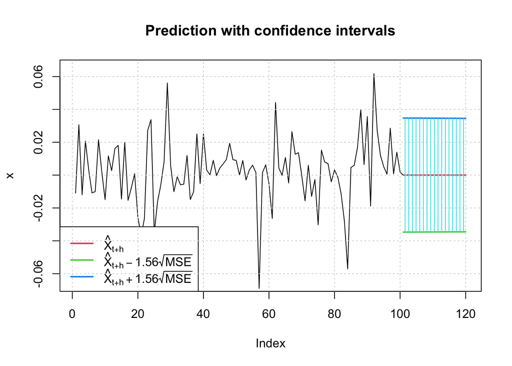

```r
predb = predict(bmw.t,n.ahead = 20, plot=TRUE, conf = .9,nx = 100)
```

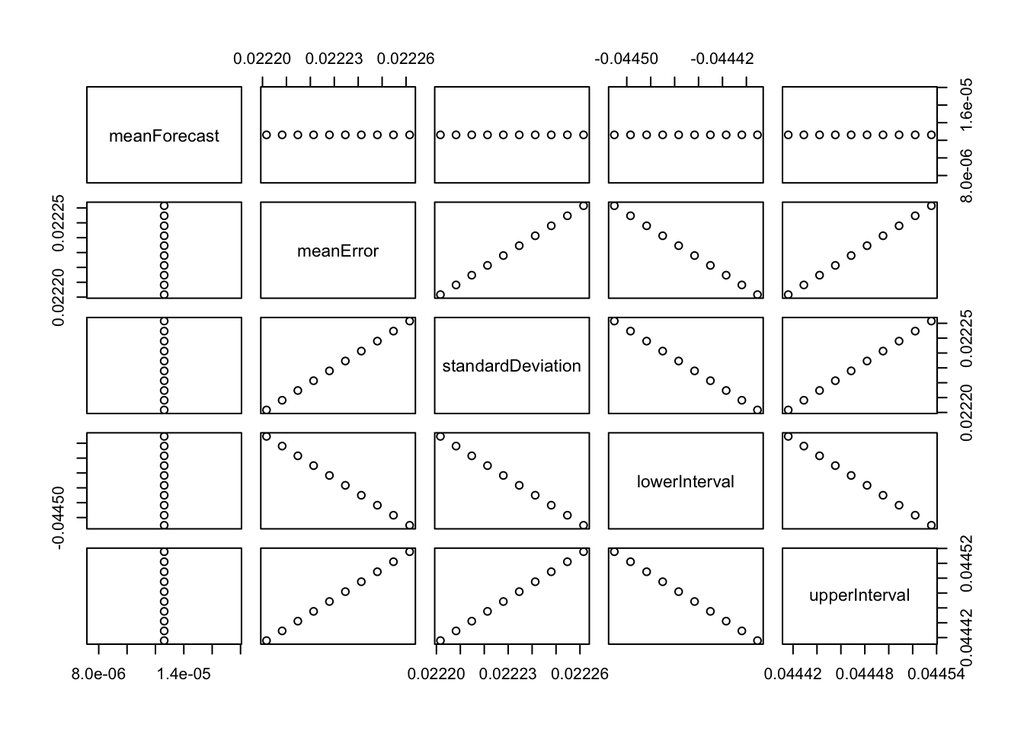

```r
plot(preda)
```

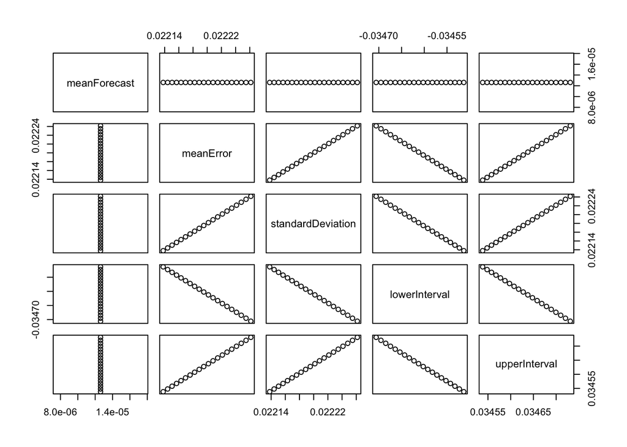

```r
plot(predb)
```

## 2. VAR con BMW y Volkswagen.

EL vector autorregresivo se utiliza para estudiar la relación bidireccional entre las variables, es decir, todas influyen en todas. Puesto que se aplica a series estacionarias, utilizaremos las diferencias para realizar la conversión.

```r
bmw.ret <- diff(log(bmw.ad))
volks.ret <- diff(log(volks.ad))
```

```r
VARselect(auto)
```

```
## $selection
## AIC(n)  HQ(n)  SC(n) FPE(n)
##      7      4      1      7
##
## $criteria
##                    1             2             3             4             5
## AIC(n) -1.671843e+01 -1.672337e+01 -1.672414e+01 -1.673296e+01 -1.673345e+01
## HQ(n)  -1.671144e+01 -1.671171e+01 -1.670781e+01 -1.671197e+01 -1.670780e+01
## SC(n)  -1.669952e+01 -1.669185e+01 -1.668001e+01 -1.667622e+01 -1.666410e+01
## FPE(n)  5.486269e-08  5.459233e-08  5.455059e-08  5.407149e-08  5.404510e-08
##                    6             7             8             9            10
## AIC(n) -1.674174e+01 -1.674204e+01 -1.674021e+01 -1.673647e+01 -1.673461e+01
## HQ(n)  -1.671143e+01 -1.670706e+01 -1.670057e+01 -1.669216e+01 -1.668565e+01
## SC(n)  -1.665979e+01 -1.664747e+01 -1.663303e+01 -1.661668e+01 -1.660222e+01
## FPE(n)  5.359863e-08  5.358299e-08  5.368092e-08  5.388216e-08  5.398223e-08
```

```r
var = VAR(auto)
summary(var)
```

```
##
## VAR Estimation Results:
## =========================
## Endogenous variables: BMW.DE.Adjusted, VOW.DE.Adjusted
## Deterministic variables: const
## Sample size: 1740
## Log Likelihood: 9615.53
## Roots of the characteristic polynomial:
## 0.06072 0.04127
## Call:
## VAR(y = auto)
##
##
## Estimation results for equation BMW.DE.Adjusted:
## ================================================
## BMW.DE.Adjusted = BMW.DE.Adjusted.l1 + VOW.DE.Adjusted.l1 + const
##
##                      Estimate Std. Error t value Pr(>|t|)
## BMW.DE.Adjusted.l1 -0.0671688  0.0363285  -1.849 0.064638 .
## VOW.DE.Adjusted.l1  0.1102278  0.0317281   3.474 0.000525 ***
## const               0.0001300  0.0004214   0.308 0.757771
## ---
## Signif. codes:  0 '***' 0.001 '**' 0.01 '*' 0.05 '.' 0.1 ' ' 1
##
##
## Residual standard error: 0.01758 on 1737 degrees of freedom
## Multiple R-Squared: 0.007673,    Adjusted R-squared: 0.00653
## F-statistic: 6.715 on 2 and 1737 DF,  p-value: 0.001244
##
##
## Estimation results for equation VOW.DE.Adjusted:
## ================================================
## VOW.DE.Adjusted = BMW.DE.Adjusted.l1 + VOW.DE.Adjusted.l1 + const
##
##                      Estimate Std. Error t value Pr(>|t|)
## BMW.DE.Adjusted.l1 -3.005e-02  4.166e-02  -0.721   0.4707
## VOW.DE.Adjusted.l1  8.663e-02  3.638e-02   2.381   0.0174 *
## const               2.321e-05  4.832e-04   0.048   0.9617
## ---
## Signif. codes:  0 '***' 0.001 '**' 0.01 '*' 0.05 '.' 0.1 ' ' 1
##
##
## Residual standard error: 0.02015 on 1737 degrees of freedom
## Multiple R-Squared: 0.004769,    Adjusted R-squared: 0.003623
## F-statistic: 4.161 on 2 and 1737 DF,  p-value: 0.01574
##
##
##
## Covariance matrix of residuals:
##                 BMW.DE.Adjusted VOW.DE.Adjusted
## BMW.DE.Adjusted       0.0003089       0.0002664
## VOW.DE.Adjusted       0.0002664       0.0004062
##
## Correlation matrix of residuals:
##                 BMW.DE.Adjusted VOW.DE.Adjusted
## BMW.DE.Adjusted           1.000           0.752
## VOW.DE.Adjusted           0.752           1.000
```

Realizamos la predicción y obtenemos representamos las funciones impulso-respuesta.

```r
var.pred <- predict(var, n.ahead = 10, ci = 0.95)
Phi(var)
```

```
## , , 1
##
##      [,1] [,2]
## [1,]    1    0
## [2,]    0    1
##
## , , 2
##
##             [,1]       [,2]
## [1,] -0.06716878 0.11022780
## [2,] -0.03005392 0.08662732
##
## , , 3
##
##               [,1]        [,2]
## [1,]  0.0011988666 0.002144872
## [2,] -0.0005848054 0.004191514
##
## , , 4
##
##               [,1]         [,2]
## [1,] -1.449882e-04 0.0003179529
## [2,] -8.669077e-05 0.0002986378
##
## , , 5
##
##               [,1]         [,2]
## [1,]  1.829484e-07 1.156168e-05
## [2,] -3.152324e-06 1.631446e-05
##
## , , 6
##
##               [,1]         [,2]
## [1,] -3.597621e-07 1.021723e-06
## [2,] -2.785757e-07 1.065804e-06
##
## , , 7
##
##            [,1]         [,2]
## [1,] -6.542e-09 4.885332e-08
```

[output cut: 10 more lines]

```
##               [,1]         [,2]
## [1,] -3.641267e-11 1.907376e-10
## [2,] -5.200516e-11 2.297153e-10
##
## , , 10
##
##               [,1]         [,2]
## [1,] -3.286619e-12 1.250940e-11
## [2,] -3.410723e-12 1.416721e-11
##
## , , 11
##
##               [,1]         [,2]
## [1,] -1.551983e-13 7.213789e-13
## [2,] -1.966860e-13 8.513105e-13
```

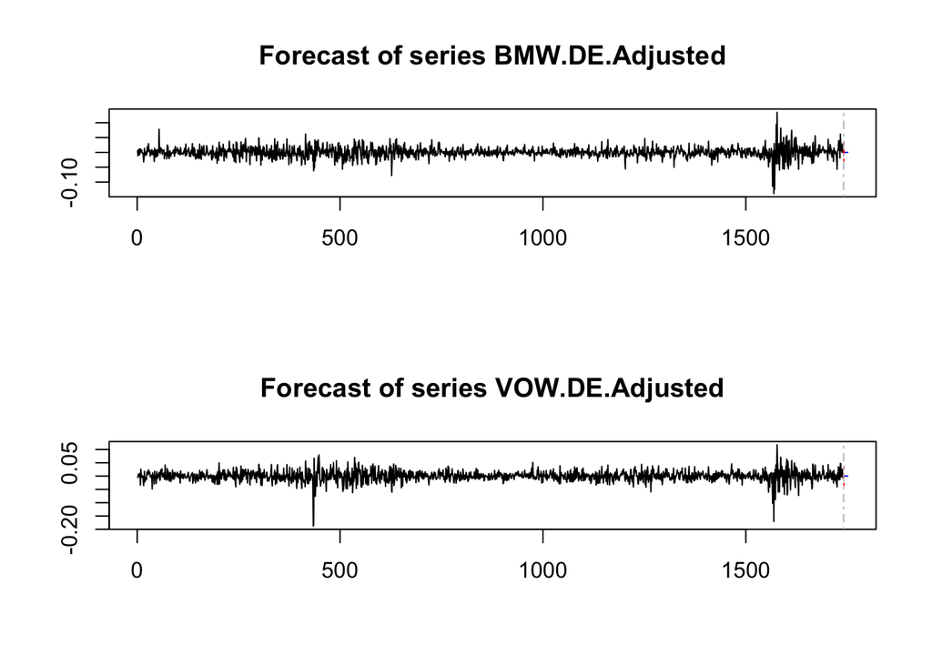

```r
plot(var.pred)
```

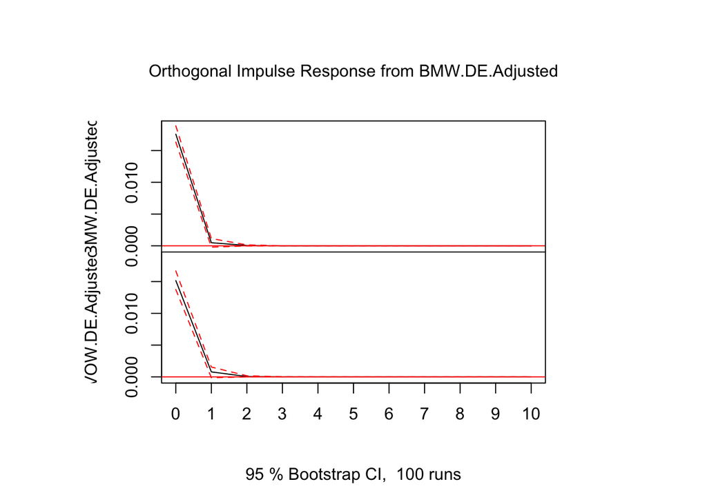

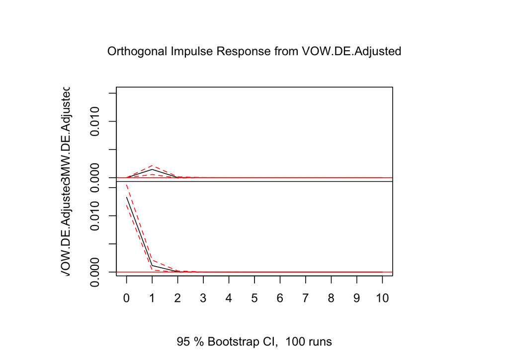

```r
var.irf <- irf(var)
plot(var.irf)
```